# AI/ML for Healthcare Applications : Text Representation and Classification using Bag-of-words (R Version)

Based on material from the Georgetown [Health Informatics and Data Science](https://healthinformatics.georgetown.edu) program and licensed under [CC4.0](https://creativecommons.org/licenses/by/4.0/)

In this demo, we will explore how to represent textual data for Machine Learning. In this first part we will explore the **Bag of Words** representation of enconding text to vectors

```r
library(data.table)
```

### The Bag of Words representation

Text Analysis is a major application field for machine learning algorithms. However the raw data, a sequence of symbols cannot be fed directly to the algorithms themselves as most of them expect numerical feature vectors with a fixed size rather than the raw text documents with variable length.

In order to address this, scikit-learn provides utilities for the most common ways to extract numerical features from text content, namely:

- **tokenizing** strings and giving an integer id for each possible token, for instance by using whitespaces and punctuation as token separators.
- **counting** the occurrences of tokens in each document.
- **normalizing** and weighting with diminishing importance tokens that occur in the majority of samples / documents.

In this scheme, features and samples are defined as follows:

- each **individual token occurrence frequenc**y (normalized or not) is treated as a feature.
- the vector of all the token frequencies for a given **document** is considered a multivariate sample.

A corpus of documents can thus be represented by a matrix with one row per document and one column per token (e.g. word) occurring in the corpus.

We call vectorization the general process of turning a collection of text documents into numerical feature vectors. This specific stragegy (tokenization, counting and normalization) is called the Bag of Words or “Bag of n-grams” representation. Documents are described by word occurrences while completely ignoring the relative position information of the words in the document.

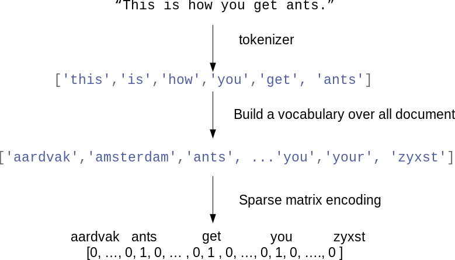

### Sparsity

As most documents will typically use a very subset of a the words used in the corpus, the resulting matrix will have many feature values that are zeros (typically more than 99% of them).

For instance a collection of 10,000 short text documents (such as emails) will use a vocabulary with a size in the order of 100,000 unique words in total while each document will use 100 to 1000 unique words individually.

In order to be able to store such a matrix in memory but also to speed up algebraic operations matrix / vector, implementations will typically use a sparse representation such as the implementations available in the `scipy.sparse`package.

### Count Vectorizer

The `CountVectorizer` function in R (https://search.r-project.org/CRAN/refmans/superml/html/CountVectorizer.html) implements both tokenization and occurrence counting in a single class:

**Bag-of-words on a toy dataset**

Some terms:

**document** - refers to a single piece of text information. This could be a text message, tweet, email, book, lyrics to a song. This is equivalent to one row or observation.

**corpus** - a collection of documents. This would be equivalent to a whole data set of rows/observations.

**token** - this is a word, phrase, or symbols derived from a document through the process of tokenization.

```r
messages <- c(
  "Patient A received an immunotherapy and got skin rash",
  "Patient B received chemotherapy instead of an immunotherapy"
)
```

We’ll use CountVectorizer() to create a matrix of numbers to represent our messages. CountVectorizer() takes what’s called the Bag of Words approach. Each message is seperated into tokens and the number of times each token occurs in a message is counted.

We’ll import CountVectorizer and instantiate it as an object, similar to how you would with a classifier from sklearn. In fact the usage is very similar. Instead of using fit() and then predict() we will use fit() then transform() or in one step fit_transform()

```r
if (!requireNamespace("superml", quietly = TRUE)) install.packages("superml")

library(superml)
```

```r
# Initialize a Count Vectorizer
vect <- CountVectorizer$new()
```

```r
vect
```

```
<CountVectorizer>
  Public:
    clone: function (deep = FALSE)
    fit: function (sentences)
    fit_transform: function (sentences)
    initialize: function (min_df, max_df, max_features, ngram_range, regex, remove_stopwords,
    lowercase: TRUE
    max_df: 1
    max_features: NULL
    min_df: 1
    model: NULL
    ngram_range: 1 1
    regex: [^a-zA-Z0-9 ]
    remove_stopwords: TRUE
    sentences: NA
    split:
    transform: function (sentences)
  Private:
    check_args: function (x, max_value, what)
    get_bow_df: function (sentences, use_tokens = NULL)
    get_tokens: function (sentences, min_df = 1, max_df = 1, ngram_range = NULL,
    preprocess: function (sentences, regex = "[^0-9a-zA-Z ]", lowercase, remove_stopwords)
```

This model has many parameters, however the default values are quite reasonable. Full parameter details: https://search.r-project.org/CRAN/refmans/superml/html/CountVectorizer.html

In one step: **fit_transform()**

```r
vect <- CountVectorizer$new()
```

```r
messages
```

1. 'Patient A received an immunotherapy and got skin rash'

2. 'Patient B received chemotherapy instead of an immunotherapy'

```r
X <- vect$fit_transform(messages)
```

```r
X
```

A matrix: 2 × 9 of type dbl

| received | patient | immunotherapy | skin | rash | instead | got | chemotherapy | b |
| --- | --- | --- | --- | --- | --- | --- | --- | --- |
| 1 | 1 | 1 | 1 | 1 | 0 | 1 | 0 | 0 |
| 1 | 1 | 1 | 0 | 0 | 1 | 0 | 1 | 1 |

```r
dense_matrix <- as.matrix(X)
dim(dense_matrix)
```

1. 2

2. 9

```r
# Get the feature names
feature_names <- colnames(X)
print(feature_names)
```

```
[1] "received"      "patient"       "immunotherapy" "skin"
[5] "rash"          "instead"       "got"           "chemotherapy"
[9] "b"
```

```r
# Convert to a data frame
df <- as.data.frame(dense_matrix)
#colnames(df) <- feature_names
print(df)
```

```
  received patient immunotherapy skin rash instead got chemotherapy b
1        1       1             1    1    1       0   1            0 0
2        1       1             1    0    0       1   0            1 1
```

#### Going beyond 1-grams

```r
messages
```

1. 'Patient A received an immunotherapy and got skin rash'

2. 'Patient B received chemotherapy instead of an immunotherapy'

To preserve some of the local ordering information we can extract 2-grams of words in addition to the 1-grams (the word themselvs):

```r
# Initialize CountVectorizer with bigram settings
bigram_vectorizer <- CountVectorizer$new(ngram_range = c(1, 2))

# Fit and transform the messages
dtm_bigrams <- bigram_vectorizer$fit_transform(messages)

# Convert the sparse matrix to a dense matrix
dense_matrix_bigrams <- as.matrix(dtm_bigrams)
```

```r
bigram_vectorizer$fit_transform('Bi-grams are cool!')
```

A matrix: 1 × 5 of type dbl

| grams cool | grams | cool | bi grams | bi |
| --- | --- | --- | --- | --- |
| 1 | 1 | 1 | 1 | 1 |

```r
dtm_bigrams
```

A matrix: 2 × 16 of type dbl

| received | patient received | patient | immunotherapy | skin rash | skin | received immunotherapy | received chemotherapy | rash | instead immunotherapy | instead | immunotherapy got | got skin | got | chemotherapy instead | chemotherapy |
| --- | --- | --- | --- | --- | --- | --- | --- | --- | --- | --- | --- | --- | --- | --- | --- |
| 1 | 1 | 1 | 1 | 1 | 1 | 1 | 0 | 1 | 0 | 0 | 1 | 1 | 1 | 0 | 0 |
| 1 | 0 | 1 | 1 | 0 | 0 | 0 | 1 | 0 | 1 | 1 | 0 | 0 | 0 | 1 | 1 |

```r
dim(dense_matrix_bigrams)
```

1. 2

2. 16

```r
colnames(dense_matrix_bigrams)
```

1. 'received'

2. 'patient received'

3. 'patient'

4. 'immunotherapy'

5. 'skin rash'

6. 'skin'

7. 'received immunotherapy'

8. 'received chemotherapy'

9. 'rash'

10. 'instead immunotherapy'

11. 'instead'

12. 'immunotherapy got'

13. 'got skin'

14. 'got'

15. 'chemotherapy instead'

16. 'chemotherapy'

```r
# Convert the dense matrix to a data frame with proper column names
df_bigrams <- as.data.frame(dense_matrix_bigrams)
print("Document-Term Matrix with Bigrams:")
print(df_bigrams)
```

```
[1] "Document-Term Matrix with Bigrams:"
  received patient received patient immunotherapy skin rash skin
1        1                1       1             1         1    1
2        1                0       1             1         0    0
  received immunotherapy received chemotherapy rash instead immunotherapy
1                      1                     0    1                     0
2                      0                     1    0                     1
  instead immunotherapy got got skin got chemotherapy instead chemotherapy
1       0                 1        1   1                    0            0
2       1                 0        0   0                    1            1
```

### TF-IDF normalization

In a large text corpus, some words will be very present (e.g. “the”, “a”, “is” in English) hence carrying very little meaningul information about the actual contents of the document. If we were to feed the direct count data directly to a classifier those very frequent terms would shadow the frequencies of rarer yet more interesting terms.

In order to re-weight the count features into floating point values suitable for usage by a classifier it is very common to use the tf–idf transform.

Tf means **term-frequency** while tf–idf means term-frequency times **inverse document-frequency**. This is a orginally a term weighting scheme developed for information retrieval (as a ranking function for search engines results), that has also found good use in document classification and clustering.

To generalize: `TF-IDF = term frequency * (1 / document frequency)`

Or: `TF-IDF = term frequency * inverse document frequency`

Term frequency is a weight representing how often a word occurs in a document. If we have several occurences of the same word in one document we can expect the TF-IDF to increase.

Inverse document frequency is another weight representing how common a word is across documents. If a word is used in many documents then the TF-IDF will decrease.

There are many ways to calculate the TF-IDF, but all essentially calculate the same concept.

tfidf(w,d) = tf * log((N+1)/(Nw +1 )) +1

```r
# Initialize TfidfVectorizer
tfidf_vectorizer <- TfIdfVectorizer$new()
```

```r
messages <- c(
  "Patient A received an immunotherapy and got skin rash",
  "Patient B received chemotherapy instead of an immunotherapy"
)
```

```r
# Fit and transform the messages
tfidf_matrix <- tfidf_vectorizer$fit_transform(messages)
```

```r
vocabulary_size <-length(colnames(tfidf_matrix))
cat("Vocabulary size:", vocabulary_size, "\n")

cat("Vocabulary content:", colnames(tfidf_matrix), "\n")
```

```
Vocabulary size: 9
Vocabulary content: received patient immunotherapy skin rash instead got chemotherapy b
```

```r
tfidf_vectorizer
```

```
<TfIdfVectorizer>
  Inherits from: <CountVectorizer>
  Public:
    clone: function (deep = FALSE)
    fit: function (sentences)
    fit_transform: function (sentences)
    initialize: function (min_df, max_df, max_features, ngram_range, regex, remove_stopwords,
    lowercase: TRUE
    max_df: 1
    max_features: NULL
    min_df: 1
    model: 1 1 1 1 1 1 1 0 1 0 0 1 1 0 0 1 0 1
    ngram_range: 1 1
    norm: TRUE
    regex: [^a-zA-Z0-9 ]
    remove_stopwords: TRUE
    sentences: patient received immunotherapy got skin rash patient b r ...
    smooth_idf: TRUE
    split:
    transform: function (sentences)
  Private:
    check_args: function (x, max_value, what)
    get_bow_df: function (sentences, use_tokens = NULL)
    get_tokens: function (sentences, min_df = 1, max_df = 1, ngram_range = NULL,
    gettfmatrix: function (countmatrix, sentences, norm, smooth_idf = TRUE)
    preprocess: function (sentences, regex = "[^0-9a-zA-Z ]", lowercase, remove_stopwords)
```

```r
# Convert the sparse matrix to a dense matrix
dense_matrix_tfidf <- as.matrix(tfidf_matrix)

# Convert to a data frame for better readability
df_tfidf <- as.data.frame(dense_matrix_tfidf)
cat("TF-IDF Matrix:\n")
print(df_tfidf)
```

```
TF-IDF Matrix:
   received   patient immunotherapy      skin      rash   instead       got
1 0.3347123 0.3347123     0.3347123 0.4704264 0.4704264 0.0000000 0.4704264
2 0.3347123 0.3347123     0.3347123 0.0000000 0.0000000 0.4704264 0.0000000
  chemotherapy         b
1    0.0000000 0.0000000
2    0.4704264 0.4704264
```

```r
tfidf_matrix
```

A matrix: 2 × 9 of type dbl

| received | patient | immunotherapy | skin | rash | instead | got | chemotherapy | b |
| --- | --- | --- | --- | --- | --- | --- | --- | --- |
| 0.3347123 | 0.3347123 | 0.3347123 | 0.4704264 | 0.4704264 | 0.0000000 | 0.4704264 | 0.0000000 | 0.0000000 |
| 0.3347123 | 0.3347123 | 0.3347123 | 0.0000000 | 0.0000000 | 0.4704264 | 0.0000000 | 0.4704264 | 0.4704264 |

**Ending notes**

When instantiating your vectorizer there are a few arguments to tweak that can help downstream ML models

- max_features = n : only considers the top n words orderd by term frequency
- min_df = n : ignores words with a document frequency below n
- max_df = n : ignores words with a document frequency above n
- stop_words = [’ ‘] : ignores common words like 'the', 'that', 'which', etc. You’ll need to define in a list what words you want to include. There are lists of common stop words available online, the NLTK library also has a list of stop words built into it.

# Text Classification using Bag of Words

```r
# Load necessary libraries
library(data.table)  # For data manipulation
library(ggplot2)     # For plotting
```

### Dataset

For this workshop of text classification, we will using a corpus of adverse drug reaction sentences collected from PubMed articles.

Full details of the raw corpus can be found here: https://pubmed.ncbi.nlm.nih.gov/22554702/

Raw corpus link: https://sites.google.com/site/adecorpus/

I have preprocessed the raw corpus and generated a csv file with

- pubmed abstracts sentences with an adverse drug reaction: Posistive sentences
- pubmed abstracts sentences with no adverse drug reaction: Negative sentences

```r
# Set the directory path
data_dir <- "https://raw.githubusercontent.com/ICBI/AIMAHEAD_GU_publicCourseData/main/ML_Concepts/ade_corpus_subset.csv"

# Read the CSV file
ade_df <- read.csv(file.path(data_dir))
```

```r
head(ade_df)
```

A data.frame: 6 × 3

|  | pmid <int> | sentence <chr> | label <int> |
| --- | --- | --- | --- |
| 1 | 11174414 | Severe rash, including the Stevens-Johnson syndrome (SJS), is the major toxicity of nevirapine and is described in the package labeling with a prominent, boxed warning. | 1 |
| 2 | 12645965 | Significant systemic manifestations are rare. | 0 |
| 3 | 17172571 | Chronic paroxysmal hemicrania (CPH) is a rare primary headache syndrome, which is classified along with cluster headache and short-lasting unilateral neuralgiform headache attacks with conjunctival in… | 0 |
| 4 | 16109609 | Of twenty other patients in our practice who received gemcitabine for refractory lymphoma without developing pericardial effusion, none had received prior direct radiation to the heart. | 0 |
| 5 | 15779196 | A 74-year old white man was undergoing treatment with palliative chemotherapy for Stage IV Prostate Adenocarcinoma with multiple osteoblastic metastases. | 0 |
| 6 | 15866658 | RESULTS: Of the 18 patients treated with MMF, there were 11 men (61.1%) and seven women (38.8%), with an overall mean age of 55.5 years. | 0 |

```r
dim(ade_df)
```

1. 11272

2. 3

Positive instances

```r
ade_df[ade_df$label == 1, ]
```

A data.frame: 4272 × 3

|  | pmid <int> | sentence <chr> | label <int> |
| --- | --- | --- | --- |
| 1 | 11174414 | Severe rash, including the Stevens-Johnson syndrome (SJS), is the major toxicity of nevirapine and is described in the package labeling with a prominent, boxed warning. | 1 |
| 8 | 7696938 | Arrhythmias and cardiac arrest have been reported during amphotericin B administration but no effective technique has been described to prevent them. | 1 |
| 10 | 16298824 | Dyspnea, hypoxemia, and pleuritic chest pain occurred within 24 hours of rituximab administration, and there was no other apparent explanation. | 1 |
| 13 | 8071504 | Toxic optic neuropathy associated with ethambutol: implications for current therapy. | 1 |
| 18 | 18037876 | Multiple syncopal episodes started to occur during thalidomide treatment, and a Holter electrocardiogram showed multiple abnormalities, with an episode of sustained ventricular tachycardia. | 1 |
| 20 | 16092915 | OBJECTIVE: To our knowledge, this is the first published case report of an adolescent girl with a mitochondrial disorder and depression who displayed both new-onset psychotic and increased mood sympto… | 1 |
| 22 | 921427 | An elderly man with procainamide hydrochloride-induced lupus syndrome had a circulating anticoagulant against factor XI and a biologic false-positive (BFP) test result for syphilis. | 1 |
| 24 | 8292513 | Cerebrovascular complications of L-asparaginase therapy in children with leukemia: aphasia and other neuropsychological deficits. | 1 |
| 26 | 2219619 | An encephalopathy and cardiomyopathy developed in a seventeen-year-old girl with chemotherapy-induced renal failure while receiving an intravesical aluminum infusion for hemorrhagic cystitis. | 1 |
| 27 | 9007910 | DATA SYNTHESIS: Genetic deficiencies in DPD, the rate-limiting enzyme responsible for 5-FU catabolism, may occur in 3% or more of patients with cancer putting them at increased risk for unusually seve… | 1 |
| 28 | 11518127 | A 62-year-old woman treated with pranlukast for 2 months developed interstitial pneumonitis with a high fever. | 1 |
| 29 | 95811 | Glomerulonephritis in procainamide induced lupus erythematosus: report of a case and review of the literature. | 1 |
| 34 | 1655228 | Three patients are reported without a history of angina pectoris who had clinical and electrocardiographic evidence of myocardial ischemia during and immediately after BCNU infusion. | 1 |
| 36 | 18371508 | Adult respiratory distress syndrome after treatment with pegylated interferon alpha-2a and ribavirin. | 1 |
| 41 | 10633877 | Salicylate intoxication was excluded, and theophylline was finally incriminated. | 1 |
| 42 | 12561997 | We present a unique case of GTBM in a patient with myeloma following treatment with Melphalan. | 1 |
| 43 | 1440123 | This case report describes a 38-year-old male in whom SIADH was strongly suspected secondary to Tegretol therapy to control a seizure disorder. | 1 |
| 45 | 16436462 | Neutropenic colitis during standard dose combination chemotherapy with nedaplatin and irinotecan for testicular cancer. | 1 |
| 47 | 937377 | Finally, reserpine toxicity, in particular central nervous system (CNS) disturbances, was reported more frequently in patients also receiving barbiturates, suggesting additive CNS effects. | 1 |
| 50 | 3954165 | We presented a patient with status asthmaticus treated with a combination of theophylline and prednisone who developed a perforated gastric ulcer. | 1 |
| 53 | 2875665 | Administration of amantadine was associated with psychotic decompensations in two schizophrenic patients being maintained on concomitant neuroleptic medication. | 1 |
| 55 | 3688031 | The patient's defects may be due to methimazole teratogenicity or could represent a previously undescribed syndrome affecting ectodermal structures. | 1 |
| 57 | 9426968 | We report a case of vitiligo that occurred during the second month of interferon alpha 2a therapy for chronic active hepatitis C. | 1 |
| 60 | 9366852 | We describe a patient with the antiphospholipid syndrome who had skin necrosis develop from low-molecular weight heparin therapy at sites distant from injection sites. | 1 |
| 61 | 4014301 | This report describes the first case of insulin-induced cardiac failure in a patient without underlying heart disease. | 1 |
| 65 | 16765687 | Rapid resolution of topiramate-induced angle-closure glaucoma with methylprednisolone and mannitol. | 1 |
| 66 | 3720318 | We describe a patient in whom noncardiogenic pulmonary edema developed during intrabiliary infusion of monooctanoin. | 1 |
| 72 | 897744 | A drug addict with staphylococcal endocarditis treated with methicillin, who developed massive proteinuria and acute nephritic syndrome is described. | 1 |
| 78 | 1295628 | A 14-year-old female developed systemic lupus erythematosus (SLE)-like symptoms, rash, fever, leukopenia and positive anti-nuclear antibody (ANA) two weeks after administration of carbamazepine (CBZ; … | 1 |
| 80 | 12802933 | We report the first case, to our knowledge, of rituximab-related autoimmune hemolytic anemia. | 1 |
| ⋮ | ⋮ | ⋮ | ⋮ |
| 11177 | 12086549 | Toxic epidermal necrolysis associated with interleukin-2. | 1 |
| 11181 | 16239768 | A 56-year-old white woman with a diagnosis of reactive depression developed severe UI after a 30 days' treatment with venlafaxine 75 mg/day. | 1 |
| 11182 | 11352235 | RESULTS: Five of 70 patients who had begun leflunomide therapy had significant weight loss that could not be linked to other identifiable etiologies. | 1 |
| 11186 | 12932249 | We describe two dark-skinned patients who developed hyperpigmented skin and tongue lesions during combination therapy with IFN and ribavirin. | 1 |
| 11187 | 17526968 | We report a child with yolk sac tumor who developed localized pigmentation after the first course of chemotherapy regimen that included cisplatin, etoposide and bleomycin. | 1 |
| 11192 | 2113320 | Subglottic stenosis in Wegener's granulomatosis: development during cyclophosphamide treatment with response to carbon dioxide laser therapy. | 1 |
| 11195 | 8641617 | Both patients were then treated with a carboplatin alternative to cisplatin in the following courses, which resulted in neither a relapse of the colitis nor a recurrence of the malignancies up to this… | 1 |
| 11198 | 8961730 | Psychotic disorder associated with isoniazid. | 1 |
| 11203 | 8589490 | We report an unusual pattern of supravenous hyperpigmentation occurring after CHOP chemotherapy. | 1 |
| 11205 | 9627209 | In case 1, a total daily dose of 25 mg sertraline, with nondetectable sertraline and desmethylsertraline blood levels, resulted in a doubling of the lamotrigine blood level with symptoms of toxicity. | 1 |
| 11207 | 9796135 | Elderly patients for whom nitrate has been prescribed should be warned of the occurrence of hypotension, leading to unconsciousness. | 1 |
| 11211 | 15463865 | Ciprofloxacin-induced renal insufficiency in cystic fibrosis. | 1 |
| 11217 | 12854039 | Case 2, a 29-year-old woman, developed bilateral optic neuritis combined with numbness of the lower extremities as well as bowel and bladder dysfunction after a 22-month use of recombinant interferon … | 1 |
| 11218 | 10904571 | A 60 year-old woman with chronic renal failure developed acute proximal muscle weakness after receiving a regular dosage of colchicine. | 1 |
| 11222 | 17188061 | Visual hallucinations after intravitreal injection of bevacizumab in vascular age-related macular degeneration. | 1 |
| 11230 | 12111771 | Fludarabine induced lung toxicity must be considered in all patients who develop unexplained lung disease while receiving fludarabine. | 1 |
| 11232 | 1420650 | In this report we present four patients treated with a combination of different psychotropic drugs, in whom asterixis was triggered either by adding carbamazepine (CBZ) to a treatment regimen, or by i… | 1 |
| 11233 | 15463865 | We report two young patients with cystic fibrosis who presented with acute renal insufficiency after 2-3 weeks of oral ciprofloxacin therapy. | 1 |
| 11234 | 18431096 | We report 4 patients, 2 on methylphenidate and 2 on dextroamphetamine who presented with acral cyanosis, livedo reticularis, or Raynaud phenomenon. | 1 |
| 11238 | 14514135 | Neutrophilic eccrine hidradenitis mimicking cutaneous vasculitis in a lupus patient: a complication of cyclophosphamide. | 1 |
| 11240 | 7379406 | After ruling out a hydrotelluric source of fluorine, the patient's fluorosis was linked to chronic use of niflumic acid, following the publication in 1978 of the 2 previously reported cases affected b… | 1 |
| 11249 | 12092878 | Gelofusine allergy--the need for identification jewellery. | 1 |
| 11251 | 7962394 | The present report describes the first case of acute pancreatitis associated with danazol treatment of endometriosis. | 1 |
| 11254 | 20126479 | Spectral-domain optical coherence tomography and adaptive optics may detect hydroxychloroquine retinal toxicity before symptomatic vision loss. | 1 |
| 11256 | 17228132 | CONCLUSIONS: Acute severe hepatitis though rare is occasionally observed with EGFR inhibitors gefitinib or erlotinib. | 1 |
| 11258 | 15053046 | Agranulocytosis induced by vancomycin in an ESRD patient on CAPD. | 1 |
| 11260 | 8926752 | Zolpidem tissue concentrations in a multiple drug related death involving Ambien. | 1 |
| 11269 | 19018868 | We describe a case of severe aplastic anemia (AA) that was probably induced by lenalidomide. | 1 |
| 11270 | 10803790 | CONCLUSION: In some abstainers who take cyanamide for several years, thin septum-like liver fibrosis progresses along with the emergence of ground-glass hepatocytes. | 1 |
| 11271 | 8949576 | A potential role for renal and hepatic impairment in the observed protracted course of amiodarone-induced thyrotoxicosis is suggested. | 1 |

Negative instances

```r
ade_df[ade_df$label == 0, ]
```

A data.frame: 7000 × 3

|  | pmid <int> | sentence <chr> | label <int> |
| --- | --- | --- | --- |
| 2 | 12645965 | Significant systemic manifestations are rare. | 0 |
| 3 | 17172571 | Chronic paroxysmal hemicrania (CPH) is a rare primary headache syndrome, which is classified along with cluster headache and short-lasting unilateral neuralgiform headache attacks with conjunctival in… | 0 |
| 4 | 16109609 | Of twenty other patients in our practice who received gemcitabine for refractory lymphoma without developing pericardial effusion, none had received prior direct radiation to the heart. | 0 |
| 5 | 15779196 | A 74-year old white man was undergoing treatment with palliative chemotherapy for Stage IV Prostate Adenocarcinoma with multiple osteoblastic metastases. | 0 |
| 6 | 15866658 | RESULTS: Of the 18 patients treated with MMF, there were 11 men (61.1%) and seven women (38.8%), with an overall mean age of 55.5 years. | 0 |
| 7 | 9063259 | RESULTS: A 76-year-old woman developed X maltophilia endophthalmitis after cataract extraction. | 0 |
| 9 | 9200403 | Based on 2 case presentations - acute renal failure (ARF) due to myeloma kidney and due to angiotensin-converting enzyme inhibitor administration in the presence of transplant artery stenosis - new as… | 0 |
| 11 | 8597009 | Isoniazid inhibits the metabolism of phenytoin. | 0 |
| 12 | 14585456 | Patients who present to the Emergency Department after ingestion of excessive amounts of suflonylurea medications often have hypoglycemia refractory to dextrose administration. | 0 |
| 14 | 16393774 | The role of IFN-beta in inflammatory musculoskeletal disease is unclear. | 0 |
| 15 | 20386314 | METHODS: Retrospective case series of six eyes of three patients that developed Acanthamoeba keratitis with Synergeyes hybrid contact lens wear. | 0 |
| 16 | 9709726 | Diphenhydramine is generally considered an innocuous drug with a minimal risk for abuse and untoward side effects. | 0 |
| 17 | 8933322 | Methylene blue was administered (2 mg/kg intravenously), and the patient rapidly improved. | 0 |
| 19 | 18602303 | We present a patient with multiple intraoral ulcerations of the right buccal and alveolar mucosa that had previously been treated with nerve ablation therapy for trigeminal neuralgia. | 0 |
| 21 | 18397566 | Here, we report for the first time the induction of a subfulminant autoimmune hepatitis (AIH) after four months of a successful treatment of HCV-1b infection using peg-IFN and ribavirin, in a 48-year-… | 0 |
| 23 | 17983451 | To our knowledge, this is the first report of M. marinum occurring in a patient receiving infliximab. | 0 |
| 25 | 19643637 | The evaluation of this case report leads to a comprehensive review in the treatment choice for menorrhagia with the preceding history of a thrombotic event. | 0 |
| 30 | 11236070 | Leukopenia and agranulocytosis are well reported and dangerous haematological side-effects associated with the use of typical and atypical antipsychotics. | 0 |
| 31 | 16843118 | Best known are urticaria, erythema, and pruritus; sometimes pseudoallergic anaphylactoid reactions, and blisters are reported. | 0 |
| 32 | 9022114 | The second patient, a 60-year-old woman, was hospitalized because of a corneal ulcer in her left eye. | 0 |
| 33 | 17614805 | She was otherwise healthy and did not complain of hyperhidrosis. | 0 |
| 35 | 12921505 | Dosing in these patients requires very careful management. | 0 |
| 37 | 8447835 | Immunoblots conducted with hepatic microsomes from control and induced rats and purified rat P450s confirmed that these antibodies also recognised constitutive (3A2) and inducible (3A1) rat CYP3A prod… | 0 |
| 38 | 3301251 | An acute viral illness or reactivation of systemic lupus erythematosus were the suspected diagnoses. | 0 |
| 39 | 7897759 | We report a case of a 54-year-old female who ingested approximately 100 propoxyphene hydrochloride tablets in a suicide attempt. | 0 |
| 40 | 17512794 | The case reported here concerns the resolution of severe insomnia in a patient with global hypopituitary insufficiency upon adjustment of triple HRT to quadruple HRT. | 0 |
| 44 | 18795 | A repeat provocation test, under antihistaminic cover , failed to produce similar response. | 0 |
| 46 | 17614805 | The symptoms arose within 3-5 min after immersion in water, as a white sponge-like appearance, and resolved after a variable drying period. | 0 |
| 48 | 17997788 | She purchased cosmetic contact lenses via the Internet, and followed a contact lens care system irregularly, occasionally using tap water. | 0 |
| 49 | 18297577 | Eventually she showed apneic spells and hyperglycemia. | 0 |
| ⋮ | ⋮ | ⋮ | ⋮ |
| 11228 | 11978476 | Natamycin 5% and amphotericin 0.1% were started and continued for 8 weeks with resolution of the infiltrate and return of the best corrected visual acuity. | 0 |
| 11229 | 15013892 | PURPOSE: To report a side effect of quinacrine therapy for malaria. | 0 |
| 11231 | 9158666 | The role of chemotherapy in the induction of such secondary tumors after transplantation is discussed, and a proposal for the approach to these patients is suggested. | 0 |
| 11235 | 8983893 | Multicenter randomized study of two once daily regimens in the initial management of community-acquired respiratory tract infections in 163 children: azithromycin versus ceftibuten. | 0 |
| 11236 | 17039658 | Bland emollients and reduction in the dose of PLD resulted in resolution of the eruption. | 0 |
| 11237 | 18034202 | Obtaining appropriate cultures can be critical in making the diagnosis and directing treatment. | 0 |
| 11239 | 7696938 | After these were corrected the amphotericin B was restarted and the course of treatment completed successfully. | 0 |
| 11241 | 19031964 | RESULTS: Grade 3 and 4 toxicities were mainly hematological and manageable. | 0 |
| 11242 | 17490929 | Her physical appearance, elevated and relatively nonsuppressible plasma cortisol levels, and radiologic study supported a tentative diagnosis of Cushing's syndrome in a critically ill patient. | 0 |
| 11243 | 19676005 | Implicated triggering factors are numerous and include toxins, medications, and infectious agents. | 0 |
| 11244 | 6453500 | The causative relationship was proven by challenge. | 0 |
| 11245 | 8783701 | After the patient died, enteroviral RNA was also detected in his lungs, liver, and spleen, indicating a generalized infection. | 0 |
| 11246 | 19348867 | Pelvic dyskinesia with an outstanding response to tetrabenazine. | 0 |
| 11247 | 16820256 | Although the role of antipsychotics in this situation is speculative, development of rhabdomyolysis related to hyponatremia and/or its correction should not be underestimated and should be assessed th… | 0 |
| 11248 | 14617303 | Infective endocarditis was diagnosed by Duke's Criteria (Durack et al. | 0 |
| 11250 | 19028142 | SCs increase during chemotherapy, were often unpredictable and led to emotional consequences. | 0 |
| 11252 | 7950160 | A fibrinolytic therapy with recombinant tissue-type plasminogen activator according to the Neuhaus scheme was attempted. | 0 |
| 11253 | 11531991 | Recurrent bacteremia by Chryseobacterium indologenes in an oncology patient with a totally implanted intravascular device. | 0 |
| 11255 | 17365919 | KS is a rare complication in glomerular diseases that may (or may not) be related to immunosuppression. | 0 |
| 11257 | 2173149 | This is our first well-documented observation of persistent cutaneous anesthesia caused by a spider bite. | 0 |
| 11259 | 1587742 | Silvadene cream and Sulfamylon make up the treatment regimen for one contributor (Dr. | 0 |
| 11261 | 3101617 | Co-trimoxazole was also being administered for prophylaxis against Pneumocystis carinii infection. | 0 |
| 11262 | 6797753 | Action of intracoronary nitroglycerin in refractory coronary artery spasm. | 0 |
| 11263 | 19220316 | Two of them could not be considered primary: in one the pain was related to an underlying, pointed and benign lesion disclosed only by magnetic resonance imaging (case 1); the second one had persisten… | 0 |
| 11264 | 7773225 | Toxicities included fever, skin rash, somnolence and a generalized seizure. | 0 |
| 11265 | 7151655 | Some degree of biochemical improvement was also noted in the other cases in whom the blood lactate levels before treatment were 15, 17, and 31 mM. | 0 |
| 11266 | 6702890 | The erythroid defect fully reversed after the drug was discontinued and could not be attributed to the patient's previously treated lung carcinoma. | 0 |
| 11267 | 11109149 | A leukocytoclastic vasculitis was found in both the acute phase and in the amputated fingertips. | 0 |
| 11268 | 15259089 | Hepatitis B virus reactivation in a patient undergoing steroid-free chemotherapy. | 0 |
| 11272 | 18805724 | CASE REPORT: This 36-year-old woman had rheumatoid arthritis that proved refractory to sulfasalazine and methotrexate, which were used successively in combination with symptomatic drugs. | 0 |

```r
library(dplyr)

# Count occurrences of each unique value in the 'label' column
label_counts <- ade_df %>%
  count(label)

print(label_counts)
```

```
  label    n
1     0 7000
2     1 4272
```

```r
table(ade_df$label)
```

```
   0    1
7000 4272
```

```r
# Extracting 'sentence' and 'label' columns as vectors
X_docs <- ade_df$sentence
y <- ade_df$label
```

```r
# Checking the shapes
length(X_docs) # Equivalent to Python's X_docs.shape
length(y)      # Equivalent to Python's y.shape
```

11272

11272

```r
# Splitting the data into training and testing sets
install.packages("caret")
library(caret)

set.seed(42)
```

```r
train_index <- createDataPartition(y, p = 0.67, list = FALSE)

X_train_docs <- X_docs[train_index]
X_test_docs <- X_docs[-train_index]
y_train <- y[train_index]
y_test <- y[-train_index]
```

```r
# Checking the sizes of the splits
length(X_train_docs)
length(X_test_docs)
length(y_train)
length(y_test)
```

7553

3719

7553

3719

```r
# Counting occurrences of labels in training and testing sets
train_label_counts <- table(y_train)
test_label_counts <- table(y_test)

# Printing counts
print(train_label_counts)
print(test_label_counts)
```

```
y_train
   0    1
4679 2874
y_test
   0    1
2321 1398
```

Sample sentence

```r
X_train_docs[1:5]
```

1. 'Severe rash, including the Stevens-Johnson syndrome (SJS), is the major toxicity of nevirapine and is described in the package labeling with a prominent, boxed warning.'

2. 'Significant systemic manifestations are rare.'

3. 'Chronic paroxysmal hemicrania (CPH) is a rare primary headache syndrome, which is classified along with cluster headache and short-lasting unilateral neuralgiform headache attacks with conjunctival injection and tearing (SUNCT) as a trigeminal autonomic cephalalgia.'

4. 'A 74-year old white man was undergoing treatment with palliative chemotherapy for Stage IV Prostate Adenocarcinoma with multiple osteoblastic metastases.'

5. 'RESULTS: A 76-year-old woman developed X maltophilia endophthalmitis after cataract extraction.'

label for the above sample sentence

```r
y_train[1:5]
```

1. 1

2. 0

3. 0

4. 0

5. 0

```r
y[1:5]
```

1. 1

2. 0

3. 0

4. 0

5. 0

### Vectorize and train models

```r
library(superml)

# Initialize a TfidfVectorizer with min_df = 5 and ngram_range = (1, 2)
vect <- TfIdfVectorizer$new(min_df = 5/length(X_docs), ngram_range = c(1, 2))
```

```r
X_train_docs[1:5]
```

1. 'Severe rash, including the Stevens-Johnson syndrome (SJS), is the major toxicity of nevirapine and is described in the package labeling with a prominent, boxed warning.'

2. 'Significant systemic manifestations are rare.'

3. 'Chronic paroxysmal hemicrania (CPH) is a rare primary headache syndrome, which is classified along with cluster headache and short-lasting unilateral neuralgiform headache attacks with conjunctival injection and tearing (SUNCT) as a trigeminal autonomic cephalalgia.'

4. 'A 74-year old white man was undergoing treatment with palliative chemotherapy for Stage IV Prostate Adenocarcinoma with multiple osteoblastic metastases.'

5. 'RESULTS: A 76-year-old woman developed X maltophilia endophthalmitis after cataract extraction.'

```r
# Fit the vectorizer on the training documents and transform them
X_train <- vect$fit_transform(X_train_docs)

# Get the dimensions of the input and output
cat("X_train_docs shape:", length(X_train_docs), "\n")
cat("X_train shape:", dim(X_train), "\n")

# Print the transformed matrix
print(X_train)
```

[output not shown]

[output cut: 4986 more lines]

```r
length(X_train_docs)
```

7553

```r
X[1:5]
```

1. 1

2. 1

3. 1

4. 1

5. 1

```r
dim(X_train)
```

1. 7553

2. 5440

```r
# Extract the feature names
feature_names <- colnames(X_train)

# Number of features
cat("Number of features:", length(feature_names), "\n")

# Display feature names from index 200 to 300
feature_names[200:300]
```

```
Number of features: 5440
```

1. 'performed'

2. 'patient developed'

3. 'female'

4. 'complications'

5. 'common'

6. 'authors'

7. 'topical'

8. 'interstitial'

9. 'hypertension'

10. 'diagnosed'

11. 'despite'

12. 'changes'

13. 'surgery'

14. 'rheumatoid'

15. 'methods'

16. 'association'

17. 'artery'

18. 'therapeutic'

19. 'rheumatoid arthritis'

20. 'recurrent'

21. 'edema'

22. 'child'

23. '12'

24. 'sodium'

25. 'resolved'

26. 'lymphoma'

27. 'hours'

28. 'features'

29. 'using'

30. 'reversible'

31. 'long term'

32. 'like'

33. 'level'

34. 'left'

35. 'inhibitor'

36. 'administered'

37. 'non'

38. 'lupus'

39. 'heparin'

40. 'system'

41. 'right'

42. 'infections'

43. 'three patients'

44. 'result'

45. 'plasma'

46. 'cells'

47. 'bone marrow'

48. 'bilateral'

49. 'suggests'

50. 'steroid'

51. 'serious'

52. 'drug induced'

53. 'confirmed'

54. 'conclusion'

55. 'abnormalities'

56. 'successful'

57. 'radiation'

58. 'prolonged'

59. 'onset'

60. 'medications'

61. 'initial'

62. 'increase'

63. 'improvement'

64. 'discussed'

65. 'diabetes'

66. 'two cases'

67. 'period'

68. 'medical'

69. 'factors'

70. 'examination'

71. 'ventricular'

72. 'resulted'

73. 'primary'

74. 'previous'

75. 'occur'

76. 'hospital'

77. 'corticosteroid'

78. 'seen'

79. 'peripheral'

80. 'follow'

81. 'fibrosis'

82. 'exposure'

83. 'data'

84. 'brain'

85. 'status'

86. 'respiratory'

87. 'pneumonitis'

88. 'patients treated'

89. 'large'

90. 'daily'

91. 'coronary'

92. 'transient'

93. 'threatening'

94. 'resolution'

95. 'pressure'

96. 'malignant'

97. 'initiation'

98. 'background'

99. 'neuropathy'

100. 'knowledge'

101. 'human'

```r
# Print the dimensions of the X_train matrix
cat("X_train dimensions:\n", dim(X_train), "\n")
```

```
X_train dimensions:
 7553 5440
```

```r
# Logistic Regression Model
install.packages("glmnet")
library(glmnet)
```

```r
# Fit logistic regression
lr_model <- cv.glmnet(as.matrix(X_train), as.factor(y_train), family = "binomial", alpha = 0)
```

```r
# Naive Bayes Model
install.packages("e1071")
library(e1071)
```

```r
# Fit Naive Bayes
nb_model <- naiveBayes(as.matrix(X_train), as.factor(y_train))
```

```r
# Inspect first 5 test documents
cat("First 5 test documents:\n")
print(X_test_docs[1:5])
```

```
First 5 test documents:
[1] "Of twenty other patients in our practice who received gemcitabine for refractory lymphoma without developing pericardial effusion, none had received prior direct radiation to the heart."
[2] "RESULTS: Of the 18 patients treated with MMF, there were 11 men (61.1%) and seven women (38.8%), with an overall mean age of 55.5 years."
[3] "Dyspnea, hypoxemia, and pleuritic chest pain occurred within 24 hours of rituximab administration, and there was no other apparent explanation."
[4] "Patients who present to the Emergency Department after ingestion of excessive amounts of suflonylurea medications often have hypoglycemia refractory to dextrose administration."
[5] "The role of IFN-beta in inflammatory musculoskeletal disease is unclear."
```

Predict on X_test_docs?

```r
# Logistic Regression Predictions
y_test_pred_lr <- predict(lr_model, as.matrix(X_test_docs), type = "response") > 0.5
y_test_pred_lr <- as.numeric(y_test_pred_lr)
```

[output not shown]

We need to transform the X_test_docs to a document matrix. We apply the fitted vectorizer that was learned on the training set.

Note, its only tranform() and not fit_trasform(). We are not learning a new vectorizer, just transforming new (test) documents to a feature matrix using the one fitted on the training set.

```r
X_test <- vect$transform(X_test_docs)
```

```r
dim(X_test)
```

1. 3719

2. 5440

```r
y_test_pred_lr <- predict(lr_model, X_test, type = "response") > 0.5
y_test_pred_lr <- as.numeric(y_test_pred_lr)
```

```r
y_test_pred_lr
```

1. 0

2. 0

3. 0

4. 0

5. 0

6. 0

7. 0

8. 0

9. 1

10. 0

11. 1

12. 1

13. 0

14. 1

15. 0

16. 0

17. 0

18. 0

19. 0

20. 0

21. 1

22. 0

23. 0

24. 0

25. 1

26. 0

27. 1

28. 0

29. 0

30. 0

31. 0

32. 1

33. 0

34. 0

35. 0

36. 1

37. 1

38. 1

39. 0

40. 0

41. 0

42. 0

43. 1

44. 0

45. 0

46. 0

47. 1

48. 1

49. 0

50. 1

51. 0

52. 0

53. 1

54. 0

55. 0

56. 0

57. 0

58. 1

59. 0

60. 0

61. 0

62. 0

63. 0

64. 0

65. 1

66. 1

67. 0

68. 0

69. 1

70. 1

71. 0

72. 1

73. 0

74. 0

75. 1

76. 0

77. 1

78. 0

79. 1

80. 1

81. 0

82. 0

83. 0

84. 0

85. 0

86. 0

87. 0

88. 1

89. 0

90. 0

91. 0

92. 0

93. 0

94. 0

95. 1

96. 1

97. 0

98. 0

99. 0

100. 0

101. 1

102. 0

103. 0

104. 0

105. 0

106. 0

107. 1

108. 1

109. 0

110. 1

111. 1

112. 1

113. 0

114. 0

115. 0

116. 0

117. 0

118. 0

119. 0

120. 0

121. 0

122. 0

123. 0

124. 0

125. 0

126. 1

127. 1

128. 1

129. 0

130. 0

131. 0

132. 1

133. 0

134. 1

135. 1

136. 0

137. 0

138. 0

139. 0

140. 0

141. 0

142. 0

143. 0

144. 0

145. 0

146. 0

147. 0

148. 1

149. 0

150. 0

151. 0

152. 0

153. 0

154. 1

155. 0

156. 1

157. 0

158. 0

159. 1

160. 0

161. 0

162. 0

163. 0

164. 1

165. 0

166. 1

167. 0

168. 0

169. 1

170. 1

171. 1

172. 0

173. 0

174. 1

175. 1

176. 0

177. 0

178. 0

179. 1

180. 0

181. 0

182. 1

183. 0

184. 1

185. 1

186. 0

187. 0

188. 0

189. 1

190. 0

191. 0

192. 0

193. 1

194. 0

195. 0

196. 0

197. 1

198. 0

199. 1

200. 0

201. ⋯

202. 0

203. 0

204. 0

205. 0

206. 0

207. 1

208. 0

209. 1

210. 1

211. 1

212. 0

213. 0

214. 0

215. 1

216. 0

217. 0

218. 0

219. 0

220. 0

221. 1

222. 1

223. 0

224. 0

225. 0

226. 0

227. 1

228. 0

229. 0

230. 0

231. 0

232. 0

233. 0

234. 0

235. 0

236. 1

237. 1

238. 0

239. 0

240. 1

241. 0

242. 0

243. 0

244. 0

245. 0

246. 0

247. 0

248. 0

249. 0

250. 0

251. 1

252. 0

253. 0

254. 0

255. 0

256. 0

257. 1

258. 0

259. 0

260. 1

261. 1

262. 0

263. 0

264. 0

265. 1

266. 0

267. 0

268. 1

269. 0

270. 1

271. 1

272. 0

273. 1

274. 1

275. 1

276. 0

277. 0

278. 0

279. 0

280. 1

281. 0

282. 0

283. 0

284. 0

285. 0

286. 0

287. 0

288. 1

289. 0

290. 0

291. 1

292. 0

293. 0

294. 0

295. 0

296. 0

297. 0

298. 0

299. 1

300. 1

301. 0

302. 0

303. 0

304. 1

305. 0

306. 0

307. 0

308. 0

309. 0

310. 1

311. 1

312. 1

313. 0

314. 0

315. 0

316. 0

317. 0

318. 1

319. 0

320. 0

321. 1

322. 0

323. 0

324. 1

325. 0

326. 0

327. 1

328. 0

329. 1

330. 0

331. 0

332. 1

333. 0

334. 1

335. 0

336. 1

337. 0

338. 0

339. 1

340. 0

341. 0

342. 0

343. 0

344. 1

345. 1

346. 1

347. 0

348. 0

349. 0

350. 0

351. 0

352. 0

353. 0

354. 0

355. 0

356. 1

357. 0

358. 0

359. 0

360. 0

361. 1

362. 0

363. 0

364. 1

365. 1

366. 0

367. 1

368. 0

369. 0

370. 0

371. 0

372. 1

373. 0

374. 0

375. 0

376. 1

377. 0

378. 0

379. 0

380. 0

381. 1

382. 0

383. 0

384. 0

385. 1

386. 0

387. 0

388. 1

389. 0

390. 1

391. 0

392. 1

393. 0

394. 0

395. 0

396. 0

397. 0

398. 1

399. 1

400. 1

401. 0

```r
library(caret)         # For classification report
```

```r
# Classification Report
classification_report <- function(y_true, y_pred) {
  confusion <- confusionMatrix(as.factor(y_pred), as.factor(y_true))
  print(confusion)
}

# Print results for Logistic Regression
cat("Logistic Regression Results:\n")
classification_report(y_test, y_test_pred_lr)
```

```
Logistic Regression Results:
Confusion Matrix and Statistics

          Reference
Prediction    0    1
         0 2082  514
         1  239  884

               Accuracy : 0.7975
                 95% CI : (0.7842, 0.8103)
    No Information Rate : 0.6241
    P-Value [Acc > NIR] : < 2.2e-16

                  Kappa : 0.5509

 Mcnemar's Test P-Value : < 2.2e-16

            Sensitivity : 0.8970
            Specificity : 0.6323
         Pos Pred Value : 0.8020
         Neg Pred Value : 0.7872
             Prevalence : 0.6241
         Detection Rate : 0.5598
   Detection Prevalence : 0.6980
      Balanced Accuracy : 0.7647

       'Positive' Class : 0
```

```r
# Naive Bayes Predictions
y_test_pred_nb <- predict(nb_model, X_test)
```

```r
# Print results for Naive Bayes
cat("Naive Bayes Results:\n")
classification_report(y_test, y_test_pred_nb)
```

```
Naive Bayes Results:
Confusion Matrix and Statistics

          Reference
Prediction    0    1
         0  180   95
         1 2141 1303

               Accuracy : 0.3988
                 95% CI : (0.383, 0.4147)
    No Information Rate : 0.6241
    P-Value [Acc > NIR] : 1

                  Kappa : 0.0074

 Mcnemar's Test P-Value : <2e-16

            Sensitivity : 0.07755
            Specificity : 0.93205
         Pos Pred Value : 0.65455
         Neg Pred Value : 0.37834
             Prevalence : 0.62409
         Detection Rate : 0.04840
   Detection Prevalence : 0.07394
      Balanced Accuracy : 0.50480

       'Positive' Class : 0
```

```r
train_and_test <- function(clf, X_train, y_train, X_test, y_test, model_type = "logistic") {
  if (model_type == "logistic") {
    clf <- cv.glmnet(X_train, y_train, family = "binomial", alpha = 0)
    y_test_pred <- predict(clf, X_test, type = "response") > 0.5
    y_test_pred <- as.numeric(y_test_pred)
  } else if (model_type == "naive_bayes") {
    clf <- naiveBayes(X_train, as.factor(y_train))
    y_test_pred <- predict(clf, X_test)
  }

  # Classification report
  classification_report(y_test, y_test_pred)
}
```

```r
# Train and test Logistic Regression
cat("Logistic Regression Train and Test:\n")
train_and_test(NULL, as.matrix(X_train), y_train, as.matrix(X_test), y_test, model_type = "logistic")
```

```
Logistic Regression Train and Test:
Confusion Matrix and Statistics

          Reference
Prediction    0    1
         0 2082  514
         1  239  884

               Accuracy : 0.7975
                 95% CI : (0.7842, 0.8103)
    No Information Rate : 0.6241
    P-Value [Acc > NIR] : < 2.2e-16

                  Kappa : 0.5509

 Mcnemar's Test P-Value : < 2.2e-16

            Sensitivity : 0.8970
            Specificity : 0.6323
         Pos Pred Value : 0.8020
         Neg Pred Value : 0.7872
             Prevalence : 0.6241
         Detection Rate : 0.5598
   Detection Prevalence : 0.6980
      Balanced Accuracy : 0.7647

       'Positive' Class : 0
```

```r
# Train and test Naive Bayes
cat("Naive Bayes Train and Test:\n")
train_and_test(NULL, as.matrix(X_train), y_train, as.matrix(X_test), y_test, model_type = "naive_bayes")
```

```
Naive Bayes Train and Test:
Confusion Matrix and Statistics

          Reference
Prediction    0    1
         0  180   95
         1 2141 1303

               Accuracy : 0.3988
                 95% CI : (0.383, 0.4147)
    No Information Rate : 0.6241
    P-Value [Acc > NIR] : 1

                  Kappa : 0.0074

 Mcnemar's Test P-Value : <2e-16

            Sensitivity : 0.07755
            Specificity : 0.93205
         Pos Pred Value : 0.65455
         Neg Pred Value : 0.37834
             Prevalence : 0.62409
         Detection Rate : 0.04840
   Detection Prevalence : 0.07394
      Balanced Accuracy : 0.50480

       'Positive' Class : 0
```